# Data Science Specialism

### Module 6 - Statistical Inference (June 2015)

## Investigating a sample population of 40 random exponential values and their relationship to the natural exponential density function using the Central Limit Theorem and Law of Large Numbers.

### INTRODUCTION

The Central Limit Theorem (CLT) definition on StatTrek (2015) states “that the sampling distribution of any statistic will be NORMAL or NEARLY NORMAL if the sample size is large enough”.

How do we know that the sample is large enough? We draw on the idea of the Law of Large Numbers (LLN). As we take a LLN (running mean) of the samples eventually the probability will be equivalent to the mean (mu) of a population density function. It is at this point of equivalence onwards that we can use the number of samples that accurately reflects the population density function.

According to some statistians a sample size of 30 to 40 values is large enough to be representative of a population density function (StatTrek 2015). Is this the case? Our sample size for this analysis has been set at 40 randomly generated exponential values.

We will attempt to answer three questions as they relate to an exponential density function and they are:

1. How does the theoretical mean and sample mean compare?
2. How does the theoretical variance and sample variance compare?
3. How does the theoretical density function and sample distribution curve differ?

#### What is an exponential density function?

Before proceeding to answer our three questions we ought to determine what is a exponential density function?

The equation for an exponential curve is given as:

```
y = e^x
```

where -

y = y axis of a graph x = x axis of a graph e is known as Euler’s number (Wikipedia 2015a) as described by Leonhard Euler (Wikipedia 2015b).

e is an irrational number and the base of Natural Logarithms which were invented by John Napier (Wikipedia 2015c).

e is calculated:

```
e = 1/n!
```

The value of e is known to 1.250 billion digits of accuracy (Gourdon 1999). Here are the first 20 digits to get you started.

```
e = 2.7182818284590452353...
```

### METHODOLOGY / DATA PROCESSING

For this analysis I will generate five graphs:

Two histograms demonstrating a normal population density function (figure 1) and an exponential density function (figure 2) both using 1000 random variables.

In order to compare the distribution curves in figures 2, 4 and 5 requires the generation of mean and variance values (table 1).

### RESULTS

```r
options(scipen=999)
title <- "Table 1 Comparison of mean and variance"
EDF <- cbind("Exponential Density Function", round(mean(exponentials), digits = 4), round(var(exponentials), digits = 4))
SDC <- cbind("Sample distribution", round(mean(samplemeans), digits = 4), round(var(samplemeans), digits = 4))
RDC <- cbind("Sample distribution (first 150 variables removed)", round(mean(removed), digits = 4), round(var(removed), digits = 4))
comparison <- rbind(EDF, SDC, RDC)
colnames(comparison) <- c("analysis?", "Mean", "Variance")

row.names(comparison) <- NULL
print(title)
```

```
## [1] "Table 1 Comparison of mean and variance"
```

```r
comparison
```

```
##      analysis?                                           Mean
## [1,] "Exponential Density Function"                      "4.8751"
## [2,] "Sample distribution"                               "4.9713"
## [3,] "Sample distribution (first 150 variables removed)" "4.8903"
##      Variance
## [1,] "20.9312"
## [2,] "0.1358"
## [3,] "0.0039"
```

The five graphs:

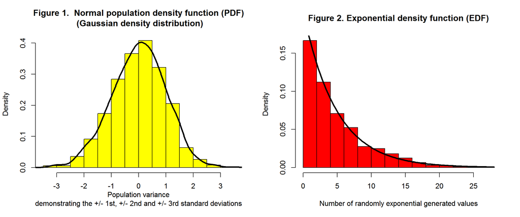

```r
par(mfrow = c(1,2))

##1 - plotting the PDF graph
hist(population, col = "yellow", main = "Figure 1.  Normal population density function (PDF)\n (Gaussian density distribution)", xlab = "Population variance\ndemonstrating the +/- 1st, +/- 2nd and +/- 3rd standard deviations", probability = TRUE)

##1.2 - plotting the density curve
lines(density(population), col = "black", lwd = 3)

    ##2 - graphic EDF
    hist(exponentials, prob = TRUE, col = "red", xlab = "Number of randomly exponential generated values", main = "Figure 2. Exponential density function (EDF)")

    ##2.1 - plotting the natural exponential line
    x.est <- fitdistr(exponentials, "exponential")$estimate

    curve(dexp(x, rate = x.est), add = TRUE, col = "black", lwd = 3)
```

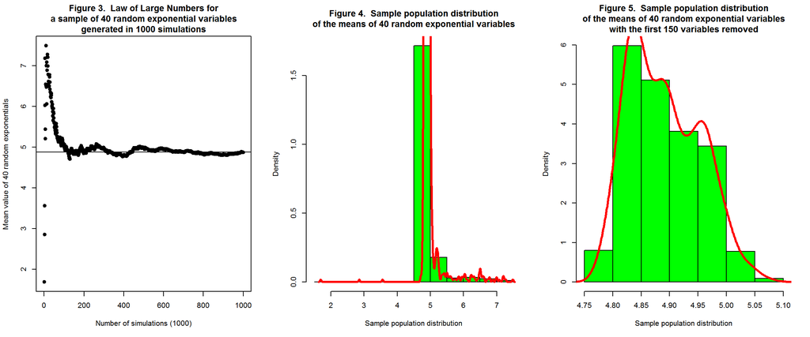

```r
par(mfrow = c(1,3))

##3 - plotting the graph of Law of Large Numbers
plot(samplemeans, xlab = "Number of simulations (1000)", ylab = "Mean value of 40 random exponentials", pch = 19, main = "Figure 3.  Law of Large Numbers for\na sample of 40 random exponential variables\ngenerated in 1000 simulations")

##3.1 - plotting a line to represent the mean value of the exponential density function
abline(h = mean(exponentials))

    ##4 - plotting a histogram of mean value of 40 exponentials
    hist(samplemeans, xlab = "Sample population distribution", col = "green", main = "Figure 4.  Sample population distribution\nof the means of 40 random exponential variables", prob = TRUE)

    ##4.1 - plotting the sample population curve
    lines(density(samplemeans), col = "red", lwd = 3)

        ##5 - re-plotting of means without first 150 samples
        hist(removed, xlab = "Sample population distribution", col = "green", main = "Figure 5.  Sample population distribution\nof the means of 40 random exponential variables\nwith the first 150 variables removed", prob = TRUE)

    ##4.1 - plotting the sample population curve
    lines(density(removed), col = "red", lwd = 3)
```